# regression (econometrics)

leechungpa

2020 11 28

# 1 데이터 로드

먼저 전체 데이터를 로드한다.

```r
data = read.csv('.\\data\\final_merge.csv')
data20 = data[year(ymd(data$date)) == 2020,]
```

# 2 EDA

다음은 데이터의 간단한 통계량과 형태이다.

```r
glimpse(data)
```

```
## Rows: 670
## Columns: 23
## $ date                  <chr> "2019-01-01", "2019-01-02", "2019-01-03", "20...
## $ seoul_covid_confirmed <dbl> 0, 0, 0, 0, 0, 0, 0, 0, 0, 0, 0, 0, 0, 0, 0, ...
## $ seoul_covid_death     <dbl> 0, 0, 0, 0, 0, 0, 0, 0, 0, 0, 0, 0, 0, 0, 0, ...
## $ seoul_covid_released  <dbl> 0, 0, 0, 0, 0, 0, 0, 0, 0, 0, 0, 0, 0, 0, 0, ...
## $ china_pm2.5           <int> 182, 182, 182, 198, 224, 106, 161, 219, 79, 9...
## $ china_pm10            <dbl> 125, 125, 133, 151, 64, 91, 159, 64, 63, 74, ...
## $ china_stock_index     <dbl> 2465.29, 2465.29, 2464.36, 2514.87, 2514.87, ...
## $ 기온                  <dbl> -5.0, -4.9, -3.5, -1.1, -2.8, -2.8, -1.9, -3.5,...
## $ 강수량                <dbl> 0, 0, 0, 0, 0, 0, 0, 0, 0, 0, 0, 0, 0, 0, 0, 0, ...
## $ 풍속                  <dbl> 2.1, 1.7, 1.4, 1.2, 2.2, 1.2, 1.4, 2.6, 1.3, 1....
## $ 최다풍향              <dbl> 290, 270, 290, 20, 290, 290, 290, 290, 50, 290, 2...
## $ 습도                  <dbl> 49.5, 42.8, 38.8, 55.5, 40.3, 35.0, 46.4, 31.0,...
## $ 기압                  <dbl> 1022.6, 1023.4, 1024.2, 1019.5, 1016.6, 1017.6,...
## $ 안개시간              <dbl> 0, 0, 0, 0, 0, 0, 0, 0, 0, 0, 0, 0, 0, 0, 0, 0, 0...
## $ y_pm2.5               <dbl> 25, 22, 24, 42, 40, 23, 37, 18, 22, 34, 57, 6...
## $ y_pm10                <dbl> 38, 34, 39, 60, 63, 49, 57, 41, 51, 58, 80, 9...
## $ transport_in          <dbl> 3534195, 4658330, 4892831, 5011360, 4434645, ...
## $ transport_out         <dbl> 3531605, 4578983, 4780205, 4946281, 4382017, ...
## $ transport_inandout    <dbl> 7065800, 9237313, 9673036, 9957641, 8816662, ...
## $ china_covid_confirmed <dbl> 0, 0, 0, 0, 0, 0, 0, 0, 0, 0, 0, 0, 0, 0, 0, ...
## $ china_covid_death     <dbl> 0, 0, 0, 0, 0, 0, 0, 0, 0, 0, 0, 0, 0, 0, 0, ...
## $ kospi_index           <dbl> 2010.00, 2010.00, 1993.70, 2010.25, 2010.25, ...
## $ soeul_oil_consumption <dbl> 3633, 2982, 2982, 2982, 2982, 2982, 2982, 298...
```

```r
skim(data)
```

Data summary

| Name | data |
| --- | --- |
| Number of rows | 670 |
| Number of columns | 23 |
| _______________________ |  |
| Column type frequency: |  |
| character | 1 |
| numeric | 22 |
| ________________________ |  |
| Group variables | None |

**Variable type: character**

| skim_variable | n_missing | complete_rate | min | max | empty | n_unique | whitespace |
| --- | --- | --- | --- | --- | --- | --- | --- |
| date | 0 | 1 | 10 | 10 | 0 | 670 | 0 |

**Variable type: numeric**

| skim_variable | n_missing | complete_rate | mean | sd | p0 | p25 | p50 | p75 | p100 | hist |
| --- | --- | --- | --- | --- | --- | --- | --- | --- | --- | --- |
| seoul_covid_confirmed | 0 | 1 | 769.81 | 1538.83 | 0.00 | 0.00 | 0.00 | 733.75 | 6011.00 | ▇▁▁▁▁ |
| seoul_covid_death | 0 | 1 | 6.48 | 16.30 | 0.00 | 0.00 | 0.00 | 4.00 | 78.00 | ▇▁▁▁▁ |
| seoul_covid_released | 0 | 1 | 586.91 | 1264.40 | 0.00 | 0.00 | 0.00 | 574.75 | 5495.00 | ▇▁▁▁▁ |
| china_pm2.5 | 2 | 1 | 106.59 | 39.49 | 17.00 | 78.00 | 102.00 | 131.00 | 282.00 | ▃▇▃▁▁ |
| china_pm10 | 0 | 1 | 62.73 | 26.13 | 4.00 | 46.00 | 59.00 | 75.00 | 197.00 | ▂▇▂▁▁ |
| china_stock_index | 0 | 1 | 2984.77 | 202.48 | 2464.36 | 2880.07 | 2954.93 | 3089.13 | 3451.09 | ▁▂▇▂▂ |
| 기온 | 0 | 1 | 14.32 | 9.72 | -8.30 | 6.30 | 15.20 | 23.10 | 31.60 | ▂▆▆▇▇ |
| 강수량 | 0 | 1 | 3.61 | 11.92 | 0.00 | 0.00 | 0.00 | 0.30 | 103.10 | ▇▁▁▁▁ |
| 풍속 | 0 | 1 | 2.15 | 0.69 | 0.60 | 1.70 | 2.00 | 2.50 | 6.00 | ▃▇▂▁▁ |
| 최다풍향 | 0 | 1 | 210.96 | 105.85 | 20.00 | 70.00 | 270.00 | 290.00 | 360.00 | ▃▁▁▇▂ |
| 습도 | 0 | 1 | 59.97 | 16.23 | 17.90 | 47.60 | 60.00 | 71.57 | 96.30 | ▁▆▇▆▃ |
| 기압 | 0 | 1 | 1003.83 | 39.64 | 0.00 | 999.30 | 1004.90 | 1011.38 | 1025.30 | ▁▁▁▁▇ |
| 안개시간 | 0 | 1 | 0.01 | 0.22 | 0.00 | 0.00 | 0.00 | 0.00 | 5.33 | ▇▁▁▁▁ |
| y_pm2.5 | 0 | 1 | 22.44 | 15.35 | 2.00 | 13.00 | 20.00 | 28.00 | 135.00 | ▇▂▁▁▁ |
| y_pm10 | 0 | 1 | 37.97 | 22.41 | 5.00 | 23.00 | 34.00 | 47.00 | 186.00 | ▇▃▁▁▁ |
| transport_in | 0 | 1 | 4633766.97 | 439141.03 | 3056490.00 | 4424019.75 | 4760874.00 | 4936478.00 | 5305274.00 | ▁▂▃▇▇ |
| transport_out | 0 | 1 | 4673159.32 | 454200.32 | 3060106.00 | 4492052.50 | 4813010.50 | 4992929.75 | 5302127.00 | ▁▁▂▆▇ |
| transport_inandout | 0 | 1 | 9306926.29 | 885463.79 | 6116596.00 | 8920641.25 | 9612497.50 | 9932750.00 | 10528041.00 | ▁▁▂▅▇ |
| china_covid_confirmed | 0 | 1 | 136.27 | 753.15 | 0.00 | 0.00 | 0.00 | 26.00 | 15141.00 | ▇▁▁▁▁ |
| china_covid_death | 0 | 1 | 7.07 | 53.97 | 0.00 | 0.00 | 0.00 | 0.00 | 1290.00 | ▇▁▁▁▁ |
| kospi_index | 0 | 1 | 2120.84 | 154.56 | 1457.64 | 2049.20 | 2130.62 | 2204.21 | 2443.58 | ▁▁▃▇▂ |
| soeul_oil_consumption | 0 | 1 | 4017.56 | 733.28 | 2979.00 | 3224.00 | 4011.00 | 4603.00 | 5462.00 | ▇▅▇▅▅ |

## 2.1 corr plot

### 2.1.1 전체 corr plot

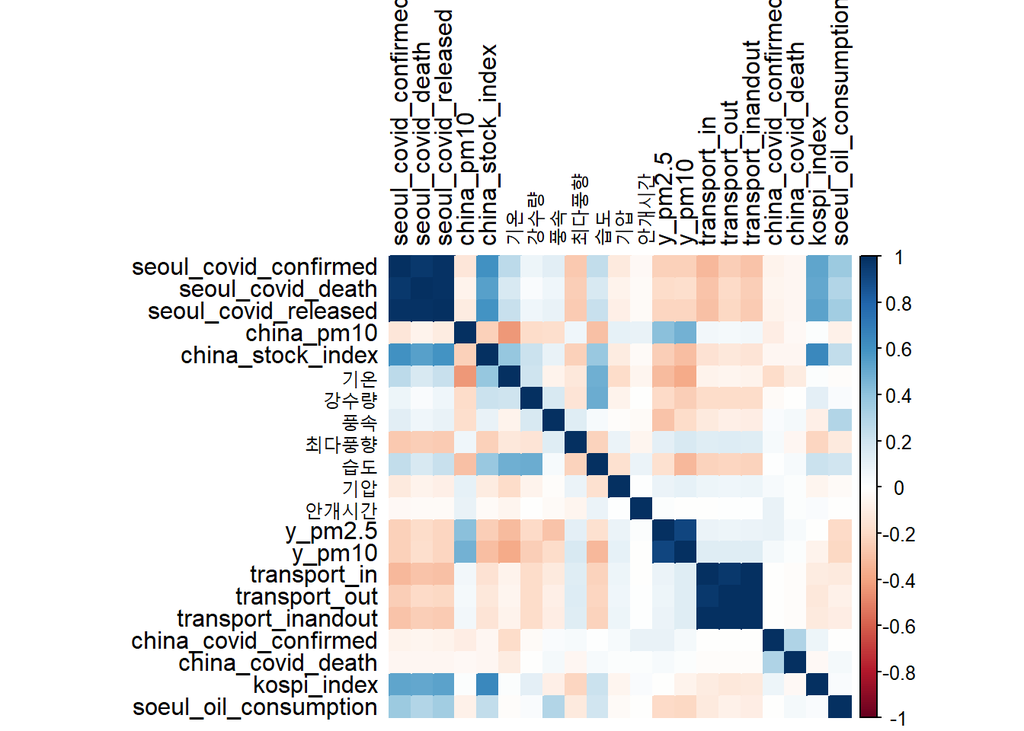

```r
data %>% select(-date, -china_pm2.5) %>%  cor() %>% corrplot(method="color", tl.col="black", title = '')
```

### 2.1.2 교통량은 inout으로 통일

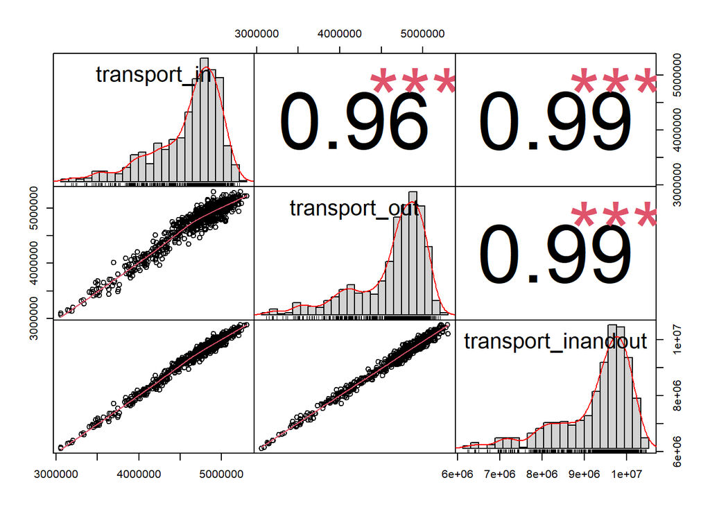

```r
corr_data = data %>% select(starts_with('transport'))
chart.Correlation(corr_data, histogram=TRUE, pch=19)
```

### 2.1.3 서울 확진자는 seoul_covid_confirmed로 통일

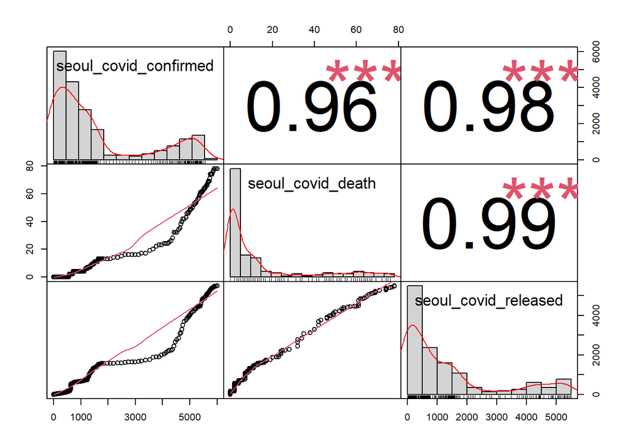

```r
corr_data = data20 %>% select(starts_with('seoul'))
chart.Correlation(corr_data, histogram=TRUE, pch=19)
```

### 2.1.4 중국도 china_covid_confirmed로 통일

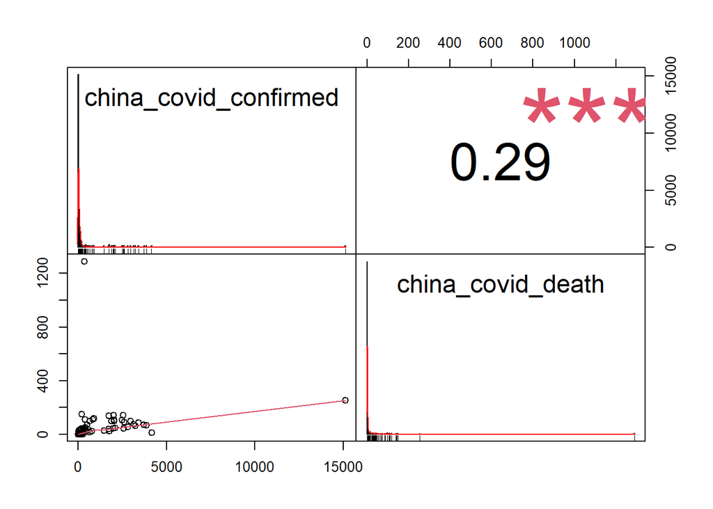

```r
corr_data = data20 %>% select(starts_with('china_covid'))
chart.Correlation(corr_data, histogram=TRUE, pch=19)
```

### 2.1.5 기온 강수량 적은 상관관계인데 일단 보류

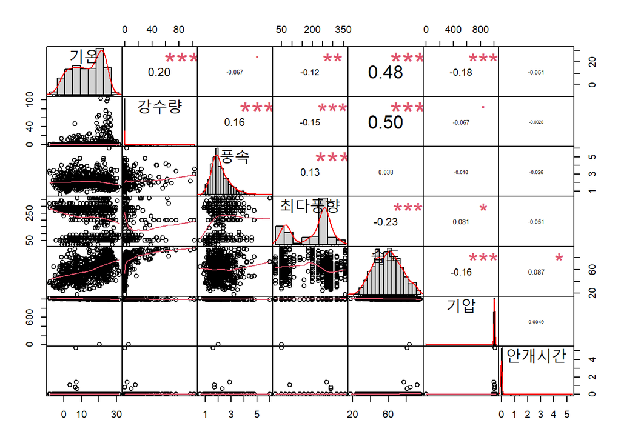

```r
corr_data = data %>% select('기온', '강수량', '풍속', '최다풍향', '습도', '기압', '안개시간')
chart.Correlation(corr_data, histogram=TRUE, pch=19)
```

### 2.1.6 중국 미세먼지/초미세먼지는 서울 y 따라감

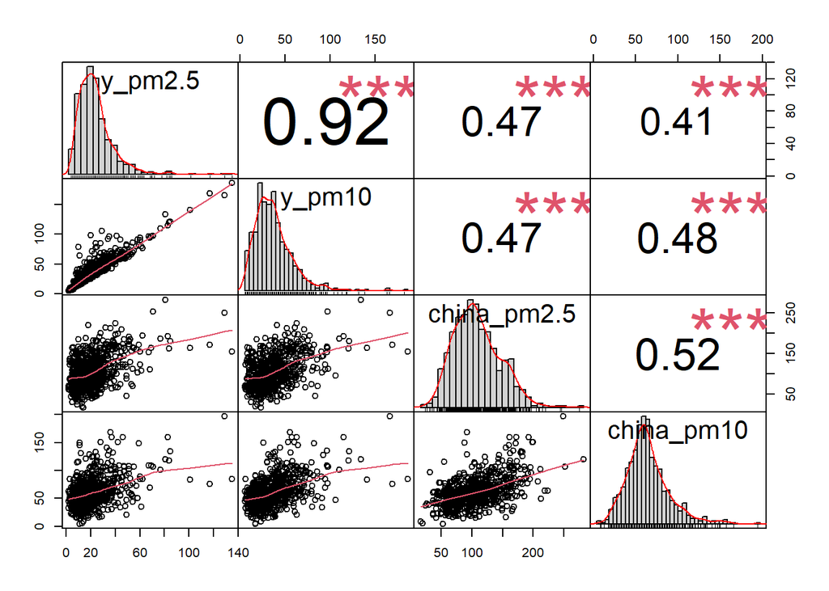

```r
corr_data = data %>% select(starts_with('y'),starts_with('china_pm'))
chart.Correlation(corr_data, histogram=TRUE, pch=19)
```

## 2.2 더미변수 변환

최다풍향 그래프

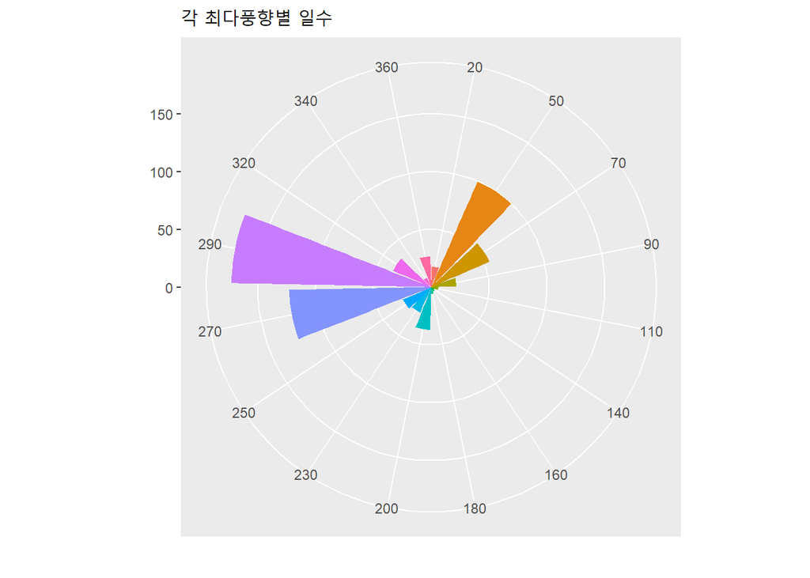

```r
data %>% mutate(최다풍향 = as.factor(최다풍향)) %>%
  ggplot(aes(x=최다풍향,  fill=최다풍향))+
  geom_bar()+
  coord_polar()+
  theme(legend.position = "none")+
  labs(title='각 최다풍향별 일수', x='',y='')
```

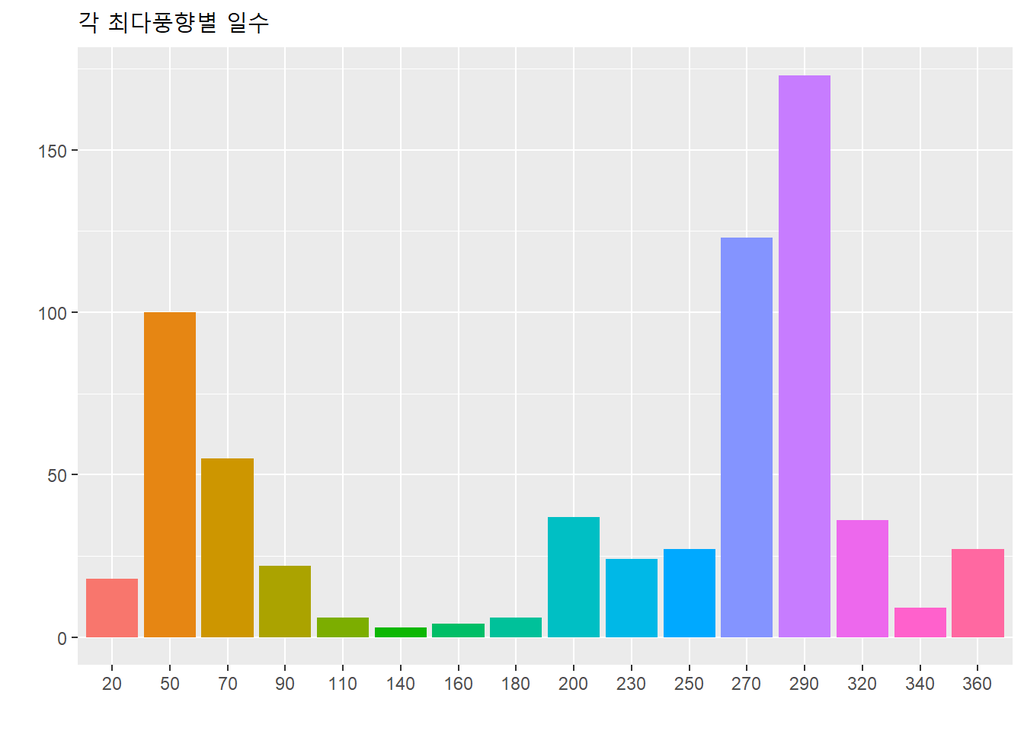

```r
data %>% mutate(최다풍향 = as.factor(최다풍향)) %>%
  ggplot(aes(x=최다풍향,  fill=최다풍향))+
  geom_bar()+
  theme(legend.position = "none")+
  labs(title='각 최다풍향별 일수', x='',y='')
```

최다풍향의 경우 90 ~ 180 또는 270~360 사이이면 1, 나머지는 0

```r
data = data %>% mutate(최다풍향 = case_when((90<=최다풍향 & 최다풍향<=180)~1,
                                           (270<=최다풍향 & 최다풍향<=360)~1,
                                           TRUE~0))

data20 = data20 %>% mutate(최다풍향 = case_when((90<=최다풍향 & 최다풍향<=180)~1,
                                           (270<=최다풍향 & 최다풍향<=360)~1,
                                           TRUE~0))
```

# 3 기본 모형

```r
lm25_1920 = lm(y_pm2.5 ~
            china_pm2.5 +  seoul_covid_confirmed +  china_stock_index +
            기온 +  강수량 +  풍속 +  최다풍향 +  습도 +  기압 +  안개시간 +
            transport_inandout +  china_covid_confirmed +  kospi_index +  soeul_oil_consumption,
          data = data)

lm25_20 = lm(y_pm2.5 ~
               china_pm2.5 +  seoul_covid_confirmed +  china_stock_index +
               기온 +  강수량 +  풍속 +  최다풍향 +  습도 +  기압 +  안개시간 +
               transport_inandout +  china_covid_confirmed +  kospi_index +  soeul_oil_consumption,
             data = data20)

lm10_1920 = lm(y_pm10 ~
                 china_pm2.5 +  seoul_covid_confirmed +  china_stock_index +
                 기온 +  강수량 +  풍속 +  최다풍향 +  습도 +  기압 +  안개시간 +
                 transport_inandout +  china_covid_confirmed +  kospi_index +  soeul_oil_consumption,
               data = data)


lm10_20 = lm(y_pm10 ~
                 china_pm2.5 +  seoul_covid_confirmed +  china_stock_index +
                 기온 +  강수량 +  풍속 +  최다풍향 +  습도 +  기압 +  안개시간 +
                 transport_inandout +  china_covid_confirmed +  kospi_index +  soeul_oil_consumption,
               data = data20)
```

## 3.1 기본 모형 결과

```r
summary(lm25_1920)
```

```
##
## Call:
## lm(formula = y_pm2.5 ~ china_pm2.5 + seoul_covid_confirmed +
##     china_stock_index + 기온 + 강수량 + 풍속 + 최다풍향 + 습도 +
##     기압 + 안개시간 + transport_inandout + china_covid_confirmed +
##     kospi_index + soeul_oil_consumption, data = data)
##
## Residuals:
##     Min      1Q  Median      3Q     Max
## -27.482  -7.505  -1.293   5.347 101.022
##
## Coefficients:
##                         Estimate Std. Error t value Pr(>|t|)
## (Intercept)            2.856e+01  1.710e+01   1.670 0.095416 .
## china_pm2.5            1.535e-01  1.398e-02  10.980  < 2e-16 ***
## seoul_covid_confirmed -3.038e-04  4.692e-04  -0.647 0.517585
## china_stock_index     -1.177e-03  4.029e-03  -0.292 0.770232
## 기온                  -2.584e-01  7.152e-02  -3.613 0.000326 ***
## 강수량                -1.451e-01  4.851e-02  -2.992 0.002875 **
## 풍속                  -5.148e+00  7.775e-01  -6.622 7.42e-11 ***
## 최다풍향               2.388e+00  1.055e+00   2.263 0.023940 *
## 습도                   1.101e-01  4.199e-02   2.622 0.008947 **
## 기압                   7.113e-04  1.245e-02   0.057 0.954459
## 안개시간              -2.051e+00  2.220e+00  -0.924 0.355853
## transport_inandout     4.781e-07  5.917e-07   0.808 0.419334
## china_covid_confirmed  9.925e-04  6.625e-04   1.498 0.134587
## kospi_index           -2.929e-03  5.120e-03  -0.572 0.567460
## soeul_oil_consumption -2.623e-03  8.078e-04  -3.247 0.001225 **
## ---
## Signif. codes:  0 '***' 0.001 '**' 0.01 '*' 0.05 '.' 0.1 ' ' 1
##
## Residual standard error: 12.45 on 653 degrees of freedom
##   (2 observations deleted due to missingness)
## Multiple R-squared:  0.3573, Adjusted R-squared:  0.3435
## F-statistic: 25.93 on 14 and 653 DF,  p-value: < 2.2e-16
```

```r
summary(lm25_20)
```

```
##
## Call:
## lm(formula = y_pm2.5 ~ china_pm2.5 + seoul_covid_confirmed +
##     china_stock_index + 기온 + 강수량 + 풍속 + 최다풍향 + 습도 +
##     기압 + 안개시간 + transport_inandout + china_covid_confirmed +
##     kospi_index + soeul_oil_consumption, data = data20)
##
## Residuals:
##      Min       1Q   Median       3Q      Max
## -20.3355  -5.9866  -0.5468   4.6370  28.7455
##
## Coefficients:
##                         Estimate Std. Error t value Pr(>|t|)
## (Intercept)            5.733e+01  1.961e+01   2.924 0.003732 **
## china_pm2.5            5.494e-02  1.565e-02   3.511 0.000518 ***
## seoul_covid_confirmed -9.044e-04  4.306e-04  -2.100 0.036583 *
## china_stock_index     -1.342e-02  6.417e-03  -2.090 0.037449 *
## 기온                  -2.553e-01  8.215e-02  -3.108 0.002071 **
## 강수량                -8.799e-02  4.057e-02  -2.169 0.030913 *
## 풍속                  -5.152e+00  7.600e-01  -6.780 6.78e-11 ***
## 최다풍향               3.149e+00  1.147e+00   2.746 0.006408 **
## 습도                   9.324e-02  4.788e-02   1.947 0.052457 .
## 기압                   8.565e-03  8.787e-03   0.975 0.330520
## 안개시간               5.026e+01  2.220e+01   2.264 0.024345 *
## transport_inandout     5.391e-07  5.593e-07   0.964 0.335895
## china_covid_confirmed -1.529e-03  1.103e-03  -1.386 0.166856
## kospi_index            6.676e-03  5.765e-03   1.158 0.247767
## soeul_oil_consumption -4.215e-03  1.780e-03  -2.368 0.018523 *
## ---
## Signif. codes:  0 '***' 0.001 '**' 0.01 '*' 0.05 '.' 0.1 ' ' 1
##
## Residual standard error: 8.705 on 289 degrees of freedom
##   (1 observation deleted due to missingness)
## Multiple R-squared:  0.4249, Adjusted R-squared:  0.397
## F-statistic: 15.25 on 14 and 289 DF,  p-value: < 2.2e-16
```

```r
summary(lm10_1920)
```

```
##
## Call:
## lm(formula = y_pm10 ~ china_pm2.5 + seoul_covid_confirmed + china_stock_index +
##     기온 + 강수량 + 풍속 + 최다풍향 + 습도 + 기압 + 안개시간 +
##     transport_inandout + china_covid_confirmed + kospi_index +
##     soeul_oil_consumption, data = data)
##
## Residuals:
##     Min      1Q  Median      3Q     Max
## -40.495 -10.874  -2.694   7.908 133.562
##
## Coefficients:
##                         Estimate Std. Error t value Pr(>|t|)
## (Intercept)            7.124e+01  2.491e+01   2.860 0.004366 **
## china_pm2.5            2.192e-01  2.035e-02  10.767  < 2e-16 ***
## seoul_covid_confirmed  9.028e-04  6.832e-04   1.321 0.186841
## china_stock_index     -4.856e-03  5.868e-03  -0.828 0.408251
## 기온                  -3.880e-01  1.042e-01  -3.725 0.000212 ***
## 강수량                -1.608e-01  7.064e-02  -2.277 0.023123 *
## 풍속                  -4.048e+00  1.132e+00  -3.575 0.000376 ***
## 최다풍향               2.765e+00  1.537e+00   1.799 0.072438 .
## 습도                  -6.413e-02  6.115e-02  -1.049 0.294704
## 기압                  -1.202e-03  1.813e-02  -0.066 0.947165
## 안개시간              -2.217e+00  3.233e+00  -0.686 0.492994
## transport_inandout     2.009e-06  8.617e-07   2.331 0.020041 *
## china_covid_confirmed  2.306e-04  9.648e-04   0.239 0.811141
## kospi_index           -1.122e-02  7.456e-03  -1.505 0.132771
## soeul_oil_consumption -4.852e-03  1.176e-03  -4.124  4.2e-05 ***
## ---
## Signif. codes:  0 '***' 0.001 '**' 0.01 '*' 0.05 '.' 0.1 ' ' 1
##
## Residual standard error: 18.13 on 653 degrees of freedom
##   (2 observations deleted due to missingness)
## Multiple R-squared:  0.3604, Adjusted R-squared:  0.3467
## F-statistic: 26.28 on 14 and 653 DF,  p-value: < 2.2e-16
```

```r
summary(lm10_20)
```

```
##
## Call:
## lm(formula = y_pm10 ~ china_pm2.5 + seoul_covid_confirmed + china_stock_index +
##     기온 + 강수량 + 풍속 + 최다풍향 + 습도 + 기압 + 안개시간 +
##     transport_inandout + china_covid_confirmed + kospi_index +
##     soeul_oil_consumption, data = data20)
##
## Residuals:
##     Min      1Q  Median      3Q     Max
## -33.186  -8.220  -1.120   6.785  74.368
##
## Coefficients:
##                         Estimate Std. Error t value Pr(>|t|)
## (Intercept)            1.064e+02  2.993e+01   3.554 0.000443 ***
## china_pm2.5            8.754e-02  2.388e-02   3.666 0.000293 ***
## seoul_covid_confirmed  2.779e-04  6.572e-04   0.423 0.672715
## china_stock_index     -1.933e-02  9.794e-03  -1.973 0.049426 *
## 기온                  -2.705e-01  1.254e-01  -2.158 0.031777 *
## 강수량                -9.415e-02  6.192e-02  -1.521 0.129476
## 풍속                  -4.833e+00  1.160e+00  -4.167 4.08e-05 ***
## 최다풍향               4.609e+00  1.750e+00   2.634 0.008904 **
## 습도                  -3.133e-02  7.307e-02  -0.429 0.668431
## 기압                   1.127e-02  1.341e-02   0.840 0.401530
## 안개시간               7.522e+01  3.389e+01   2.220 0.027202 *
## transport_inandout     1.892e-06  8.536e-07   2.217 0.027422 *
## china_covid_confirmed -2.536e-03  1.683e-03  -1.507 0.132981
## kospi_index           -6.958e-03  8.798e-03  -0.791 0.429627
## soeul_oil_consumption -4.459e-03  2.716e-03  -1.642 0.101747
## ---
## Signif. codes:  0 '***' 0.001 '**' 0.01 '*' 0.05 '.' 0.1 ' ' 1
##
## Residual standard error: 13.28 on 289 degrees of freedom
##   (1 observation deleted due to missingness)
## Multiple R-squared:  0.3938, Adjusted R-squared:  0.3644
## F-statistic: 13.41 on 14 and 289 DF,  p-value: < 2.2e-16
```

# 4 최종 모형 (stepwise 변수 선택)

[AIC](https://en.wikipedia.org/wiki/Akaike_information_criterion) 기준으로 최종 모델 선정

```r
final_model = step(lm25_20, direction = 'both')
```

```
## Start:  AIC=1330.24
## y_pm2.5 ~ china_pm2.5 + seoul_covid_confirmed + china_stock_index +
##     기온 + 강수량 + 풍속 + 최다풍향 + 습도 + 기압 + 안개시간 +
##     transport_inandout + china_covid_confirmed + kospi_index +
##     soeul_oil_consumption
##
##                         Df Sum of Sq   RSS    AIC
## - transport_inandout     1      70.4 21968 1329.2
## - 기압                   1      72.0 21970 1329.2
## - kospi_index            1     101.6 22000 1329.7
## <none>                               21898 1330.2
## - china_covid_confirmed  1     145.5 22043 1330.3
## - 습도                   1     287.3 22185 1332.2
## - china_stock_index      1     331.1 22229 1332.8
## - seoul_covid_confirmed  1     334.2 22232 1332.8
## - 강수량                 1     356.4 22254 1333.2
## - 안개시간               1     388.2 22286 1333.6
## - soeul_oil_consumption  1     425.0 22323 1334.1
## - 최다풍향               1     571.4 22469 1336.1
## - 기온                   1     732.0 22630 1338.2
## - china_pm2.5            1     934.0 22832 1340.9
## - 풍속                   1    3482.6 25381 1373.1
##
## Step:  AIC=1329.22
## y_pm2.5 ~ china_pm2.5 + seoul_covid_confirmed + china_stock_index +
##     기온 + 강수량 + 풍속 + 최다풍향 + 습도 + 기압 + 안개시간 +
##     china_covid_confirmed + kospi_index + soeul_oil_consumption
##
##                         Df Sum of Sq   RSS    AIC
## - 기압                   1      78.3 22047 1328.3
## - kospi_index            1     105.8 22074 1328.7
## - china_covid_confirmed  1     137.2 22106 1329.1
## <none>                               21968 1329.2
## + transport_inandout     1      70.4 21898 1330.2
## - 습도                   1     250.7 22219 1330.7
## - china_stock_index      1     312.4 22281 1331.5
## - soeul_oil_consumption  1     376.7 22345 1332.4
## - 안개시간               1     390.6 22359 1332.6
## - 강수량                 1     393.0 22361 1332.6
## - seoul_covid_confirmed  1     457.6 22426 1333.5
```

[output cut: 54 more lines]

```
## <none>                               22197 1326.4
## - china_stock_index      1     186.4 22384 1326.9
## + 기압                   1      72.0 22125 1327.4
## + transport_inandout     1      71.8 22126 1327.4
## - soeul_oil_consumption  1     241.7 22439 1327.7
## + china_covid_confirmed  1      50.4 22147 1327.7
## + kospi_index            1      18.4 22179 1328.1
## - 습도                   1     283.0 22481 1328.2
## - 안개시간               1     373.3 22571 1329.4
## - seoul_covid_confirmed  1     406.0 22604 1329.9
## - 강수량                 1     406.2 22604 1329.9
## - 최다풍향               1     570.3 22768 1332.1
## - 기온                   1     732.3 22930 1334.2
## - china_pm2.5            1    1052.2 23250 1338.5
## - 풍속                   1    3899.1 26097 1373.6
```

최종 모형의 결과는 다음과 같다.

```r
summary(final_model)
```

```
##
## Call:
## lm(formula = y_pm2.5 ~ china_pm2.5 + seoul_covid_confirmed +
##     china_stock_index + 기온 + 강수량 + 풍속 + 최다풍향 + 습도 +
##     안개시간 + soeul_oil_consumption, data = data20)
##
## Residuals:
##      Min       1Q   Median       3Q      Max
## -19.4314  -5.9257  -0.7999   5.2641  27.2017
##
## Coefficients:
##                         Estimate Std. Error t value Pr(>|t|)
## (Intercept)           57.5199616 15.7518402   3.652 0.000309 ***
## china_pm2.5            0.0569994  0.0152948   3.727 0.000233 ***
## seoul_covid_confirmed -0.0009297  0.0004016  -2.315 0.021301 *
## china_stock_index     -0.0066947  0.0042684  -1.568 0.117858
## 기온                  -0.2425990  0.0780320  -3.109 0.002062 **
## 강수량                -0.0931776  0.0402399  -2.316 0.021273 *
## 풍속                  -5.3397713  0.7443162  -7.174 5.98e-12 ***
## 최다풍향               3.1323166  1.1416313   2.744 0.006449 **
## 습도                   0.0882749  0.0456717   1.933 0.054223 .
## 안개시간              25.4269478 11.4553252   2.220 0.027207 *
## soeul_oil_consumption -0.0026729  0.0014964  -1.786 0.075109 .
## ---
## Signif. codes:  0 '***' 0.001 '**' 0.01 '*' 0.05 '.' 0.1 ' ' 1
##
## Residual standard error: 8.704 on 293 degrees of freedom
##   (1 observation deleted due to missingness)
## Multiple R-squared:  0.417,  Adjusted R-squared:  0.3971
## F-statistic: 20.96 on 10 and 293 DF,  p-value: < 2.2e-16
```

# 5 표준가정 확인

## 5.1 이분산성

먼저 분산 시각화 그림 (1,3만) (2번째는 정규성 같은거로 필요 없는 것)

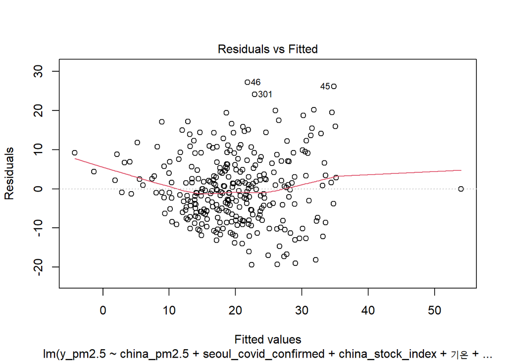

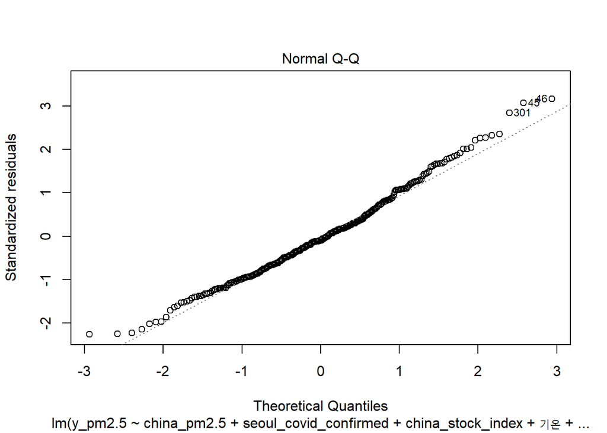

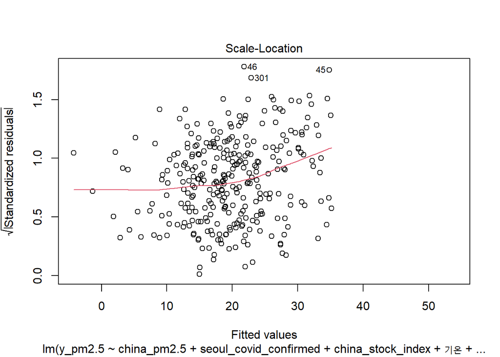

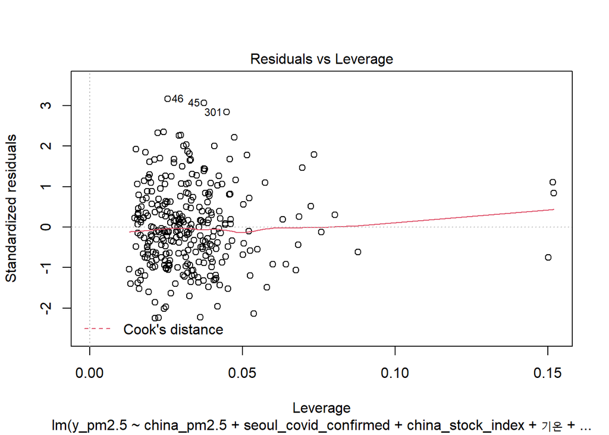

```r
plot(final_model)
```

1번째는 residuals vs fitted values

3번째는 standardised residuals on Y axis

등분산성이 만족하다면 특정한 패턴 없이 일정해야 함. 음…. 근데……. 음….. not good

### 5.1.1 Breush Pagan Test

```r
lmtest::bptest(final_model)
```

```
##
##  studentized Breusch-Pagan test
##
## data:  final_model
## BP = 39.412, df = 10, p-value = 2.149e-05
```

기각… 이분산성 존재…..

(사실 시계열 자료여서 이분산 존재하는건가)

### 5.1.2 Whites Test

```r
skedastic::white_lm(final_model)
```

```
## # A tibble: 1 x 5
##   statistic   p.value parameter method       alternative
##       <dbl>     <dbl>     <dbl> <chr>        <chr>
## 1      56.2 0.0000275        20 White's Test greater
```

마찬가지로 기각……..

## 5.2 자기상관

### 5.2.1 Durbin & G.S. Watson Test

for Serial Correlation in Least Squares Regression

```r
lmtest::dwtest(final_model)
```

```
##
##  Durbin-Watson test
##
## data:  final_model
## DW = 1.0004, p-value < 2.2e-16
## alternative hypothesis: true autocorrelation is greater than 0
```

기각… 문제있음

### 5.2.2 Breusch-Godfrey test

```r
lmtest::bgtest(final_model, order=7)
```

```
##
##  Breusch-Godfrey test for serial correlation of order up to 7
##
## data:  final_model
## LM test = 98.661, df = 7, p-value < 2.2e-16
```

기각… 문제있음

## 5.3 다중공선성

### 5.3.1 vif

```
##     china_stock_index seoul_covid_confirmed                  습도
##              3.366481              2.354626              2.235675
##                  기온                강수량 soeul_oil_consumption
##              1.991263              1.490879              1.445543
##              최다풍향           china_pm2.5                  풍속
##              1.296373              1.208596              1.117645
##              안개시간
##              1.050359
```

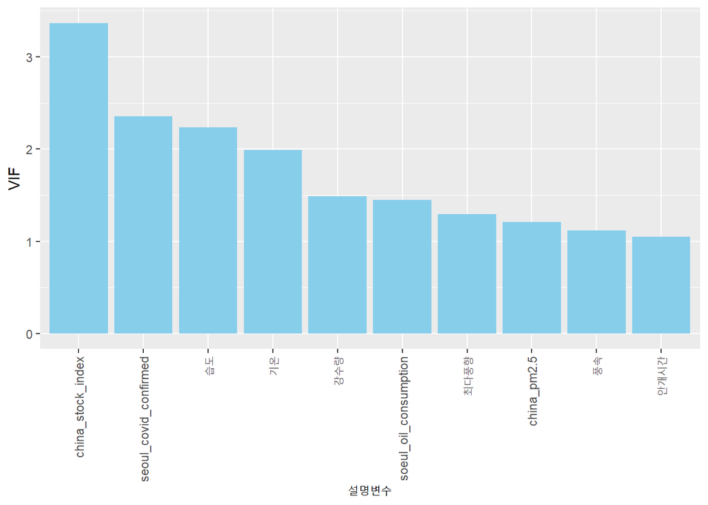

```r
car::vif(final_model) %>%
  sort(decreasing=TRUE) %>%
  print() %>%
  as_tibble(rownames = 'label') %>%
  ggplot(aes(x=reorder(label, -value, sum), y=value)) +
  geom_col(fill='skyblue') +
  labs(x='설명변수', y='VIF') +
  theme(axis.text.x = element_text(angle = 90, vjust = 0.5, hjust=1))
```

### 5.3.2 conditional index

```r
klaR::cond.index(formula = y_pm2.5 ~ `china_pm2.5` + seoul_covid_confirmed +china_stock_index +
                   기온 + 강수량 + 풍속 + 최다풍향 + 습도 +   안개시간 + soeul_oil_consumption,
                 data = data20)
```

```
##  [1]   1.000000   2.727640   2.846252   3.421689   5.205280   6.301597
##  [7]   9.322800  13.129318  18.887176  36.104670 114.151580
```

문제 있음

## 5.4 내생성

다른 변수들은 내생성이 없으나 중국 미세먼지`china_pm2.5`는 역인과관계도 발생할 수 있음. 이를 확인하고자 함

### 5.4.1 IV : china_covid_confirmed

IV로 `china_covid_confirmed` 사용한 경우

```r
model_iv = AER::ivreg(y_pm2.5 ~ china_pm2.5 + seoul_covid_confirmed + china_stock_index +
                      기온 + 강수량 + 풍속 + 최다풍향 + 습도 +  안개시간 + soeul_oil_consumption |
                      china_covid_confirmed + seoul_covid_confirmed + china_stock_index +
                      기온 + 강수량 + 풍속 + 최다풍향 + 습도 +  안개시간 + soeul_oil_consumption,
                      data = data20)

summary(model_iv, diagnostics=TRUE)
```

```
##
## Call:
## AER::ivreg(formula = y_pm2.5 ~ china_pm2.5 + seoul_covid_confirmed +
##     china_stock_index + 기온 + 강수량 + 풍속 + 최다풍향 + 습도 +
##     안개시간 + soeul_oil_consumption | china_covid_confirmed +
##     seoul_covid_confirmed + china_stock_index + 기온 + 강수량 +
##     풍속 + 최다풍향 + 습도 + 안개시간 + soeul_oil_consumption,
##     data = data20)
##
## Residuals:
##       Min        1Q    Median        3Q       Max
## -35.66418  -8.86301   0.00261   7.94299  37.34124
##
## Coefficients:
##                        Estimate Std. Error t value Pr(>|t|)
## (Intercept)           30.039939  54.959157   0.547  0.58508
## china_pm2.5           -0.227781   0.516452  -0.441  0.65950
## seoul_covid_confirmed -0.002369   0.002675  -0.886  0.37649
## china_stock_index      0.007570   0.026602   0.285  0.77619
## 기온                  -0.682196   0.804752  -0.848  0.39729
## 강수량                -0.089101   0.059914  -1.487  0.13805
## 풍속                  -6.335335   2.112579  -2.999  0.00294 **
## 최다풍향               3.469079   1.793799   1.934  0.05408 .
## 습도                   0.064274   0.080280   0.801  0.42400
## 안개시간              27.937408  17.526562   1.594  0.11201
## soeul_oil_consumption  0.003122   0.010729   0.291  0.77127
##
## Diagnostic tests:
##                  df1 df2 statistic p-value
## Weak instruments   1 293     0.562   0.454
## Wu-Hausman         1 292     0.664   0.416
## Sargan             0  NA        NA      NA
##
## Residual standard error: 12.86 on 293 degrees of freedom
## Multiple R-Squared: -0.2727, Adjusted R-squared: -0.3162
## Wald test: 8.984 on 10 and 293 DF,  p-value: 6.572e-13
```

```r
with(na.omit(data20), cor(china_pm2.5, china_covid_confirmed))
```

```
## [1] 0.09131393
```

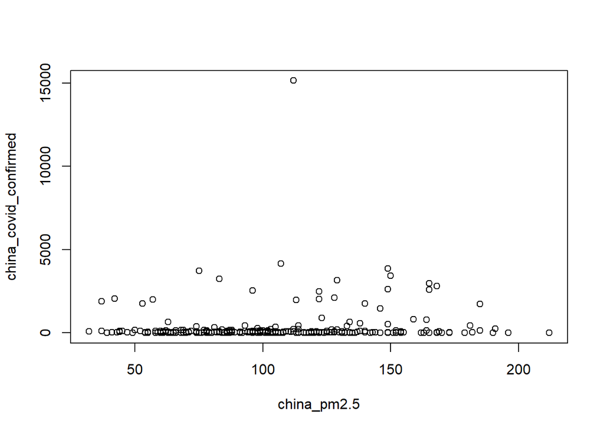

```r
with(na.omit(data20), plot(china_pm2.5, china_covid_confirmed))
```

Weak instruments로 다른 IV를 찾아야함

### 5.4.2 IV : lag_china_pm25

```r
lag_data20 = mutate(data20, lag_china_pm25=lag(china_pm2.5,1))


with(na.omit(lag_data20), cor(china_pm2.5, lag_china_pm25))
```

```
## [1] 0.6020432
```

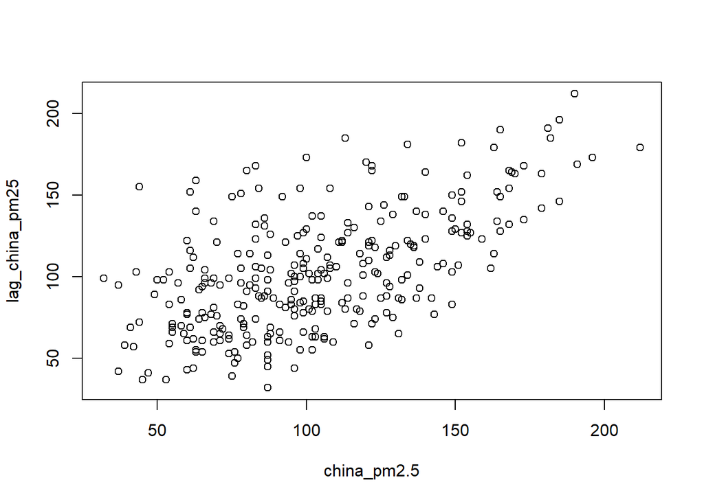

```r
with(na.omit(lag_data20), plot(china_pm2.5, lag_china_pm25))
```

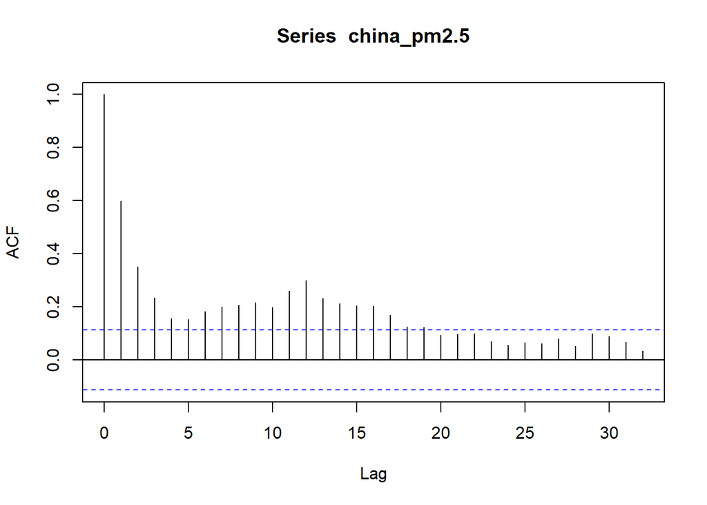

```r
with(na.omit(lag_data20), acf(china_pm2.5, lag_china_pm25))
```

아래는 IV로 `lag china_pm2.5`(하루전) 사용한 경우 : 역인과관계 차단

```r
model_iv_lag = AER::ivreg(y_pm2.5 ~ china_pm2.5 + seoul_covid_confirmed + china_stock_index +
                            기온 + 강수량 + 풍속 + 최다풍향 + 습도 +  안개시간 + soeul_oil_consumption |
                            lag_china_pm25 + seoul_covid_confirmed + china_stock_index +
                            기온 + 강수량 + 풍속 + 최다풍향 + 습도 +  안개시간 + soeul_oil_consumption,
                            data = lag_data20)
summary(model_iv_lag, diagnostics=TRUE)
```

```
##
## Call:
## AER::ivreg(formula = y_pm2.5 ~ china_pm2.5 + seoul_covid_confirmed +
##     china_stock_index + 기온 + 강수량 + 풍속 + 최다풍향 + 습도 +
##     안개시간 + soeul_oil_consumption | lag_china_pm25 + seoul_covid_confirmed +
##     china_stock_index + 기온 + 강수량 + 풍속 + 최다풍향 + 습도 +
##     안개시간 + soeul_oil_consumption, data = lag_data20)
##
## Residuals:
##     Min      1Q  Median      3Q     Max
## -20.695  -6.201  -1.043   4.901  27.197
##
## Coefficients:
##                         Estimate Std. Error t value Pr(>|t|)
## (Intercept)           56.0936745 16.0614094   3.492 0.000553 ***
## china_pm2.5            0.0311435  0.0297322   1.047 0.295750
## seoul_covid_confirmed -0.0010285  0.0004255  -2.417 0.016246 *
## china_stock_index     -0.0056516  0.0044870  -1.260 0.208844
## 기온                  -0.2718429  0.0887337  -3.064 0.002391 **
## 강수량                -0.0917886  0.0404366  -2.270 0.023940 *
## 풍속                  -5.3415568  0.7585996  -7.041 1.37e-11 ***
## 최다풍향               3.2788969  1.1520563   2.846 0.004739 **
## 습도                   0.0838466  0.0459688   1.824 0.069176 .
## 안개시간              25.7788224 11.5104638   2.240 0.025870 *
## soeul_oil_consumption -0.0022976  0.0016013  -1.435 0.152387
##
## Diagnostic tests:
##                  df1 df2 statistic p-value
## Weak instruments   1 292   106.741  <2e-16 ***
## Wu-Hausman         1 291     1.115   0.292
## Sargan             0  NA        NA      NA
## ---
## Signif. codes:  0 '***' 0.001 '**' 0.01 '*' 0.05 '.' 0.1 ' ' 1
##
## Residual standard error: 8.744 on 292 degrees of freedom
## Multiple R-Squared: 0.4073,  Adjusted R-squared: 0.387
## Wald test: 19.06 on 10 and 292 DF,  p-value: < 2.2e-16
```

```r
ivreg2 <- function(form,endog,iv,data,digits=3){
  # library(MASS)
  # model setup
  r1 <- lm(form,data)
  y <- r1$fitted.values+r1$resid
  x <- model.matrix(r1)
  aa <- rbind(endog == colnames(x),1:dim(x)[2])
  z <- cbind(x[,aa[2,aa[1,]==0]],data[,iv])
  colnames(z)[(dim(z)[2]-length(iv)+1):(dim(z)[2])] <- iv
  # iv coefficients and standard errors
  z <- as.matrix(z)
  pz <- z %*% (solve(crossprod(z))) %*% t(z)
  biv <- solve(crossprod(x,pz) %*% x) %*% (crossprod(x,pz) %*% y)
  sigiv <- crossprod((y - x %*% biv),(y - x %*% biv))/(length(y)-length(biv))
  vbiv <- as.numeric(sigiv)*solve(crossprod(x,pz) %*% x)
  res <- cbind(biv,sqrt(diag(vbiv)),biv/sqrt(diag(vbiv)),(1-pnorm(biv/sqrt(diag(vbiv))))*2)
  res <- matrix(as.numeric(sprintf(paste("%.",paste(digits,"f",sep=""),sep=""),res)),nrow=dim(res)[1])
  rownames(res) <- colnames(x)
  colnames(res) <- c("Coef","S.E.","t-stat","p-val")
  # First-stage F-test
  y1 <- data[,endog]
  z1 <- x[,aa[2,aa[1,]==0]]
  bet1 <- solve(crossprod(z)) %*% crossprod(z,y1)
  bet2 <- solve(crossprod(z1)) %*% crossprod(z1,y1)
  rss1 <- sum((y1 - z %*% bet1)^2)
  rss2 <- sum((y1 - z1 %*% bet2)^2)
  p1 <- length(bet1)
  p2 <- length(bet2)
  n1 <- length(y)
  fs <- abs((rss2-rss1)/(p2-p1))/(rss1/(n1-p1))
  firststage <- c(fs)
  firststage <- matrix(as.numeric(sprintf(paste("%.",paste(digits,"f",sep=""),sep=""),firststage)),ncol=length(firststage))
  colnames(firststage) <- c("First Stage F-test")
  # Hausman tests
  bols <- solve(crossprod(x)) %*% crossprod(x,y)
  sigols <- crossprod((y - x %*% bols),(y - x %*% bols))/(length(y)-length(bols))
  vbols <- as.numeric(sigols)*solve(crossprod(x))
  sigml <- crossprod((y - x %*% bols),(y - x %*% bols))/(length(y))
  x1 <- x[,!(colnames(x) %in% "(Intercept)")]
  z1 <- z[,!(colnames(z) %in% "(Intercept)")]
  pz1 <- z1 %*% (solve(crossprod(z1))) %*% t(z1)
  biv1 <- biv[!(rownames(biv) %in% "(Intercept)"),]
  bols1 <- bols[!(rownames(bols) %in% "(Intercept)"),]
  # Durbin-Wu-Hausman chi-sq test:
  # haus <- t(biv1-bols1) %*% ginv(as.numeric(sigml)*(solve(crossprod(x1,pz1) %*% x1)-solve(crossprod(x1)))) %*% (biv1-bols1)
  # hpvl <- 1-pchisq(haus,df=1)
  # Wu-Hausman F test
  resids <- NULL
  resids <- cbind(resids,y1 - z %*% solve(crossprod(z)) %*% crossprod(z,y1))
  x2 <- cbind(x,resids)
  bet1 <- solve(crossprod(x2)) %*% crossprod(x2,y)
  bet2 <- solve(crossprod(x)) %*% crossprod(x,y)
  rss1 <- sum((y - x2 %*% bet1)^2)
  rss2 <- sum((y - x %*% bet2)^2)
  p1 <- length(bet1)
  p2 <- length(bet2)
  n1 <- length(y)
  fs <- abs((rss2-rss1)/(p2-p1))/(rss1/(n1-p1))
  fpval <- 1-pf(fs, p1-p2, n1-p1)
  #hawu <- c(haus,hpvl,fs,fpval)
  hawu <- c(fs,fpval)
  hawu <- matrix(as.numeric(sprintf(paste("%.",paste(digits,"f",sep=""),sep=""),hawu)),ncol=length(hawu))
  #colnames(hawu) <- c("Durbin-Wu-Hausman chi-sq test","p-val","Wu-Hausman F-test","p-val")
  colnames(hawu) <- c("Wu-Hausman F-test","p-val")
  # Sargan Over-id test
  ivres <- y - (x %*% biv)
  oid <- solve(crossprod(z)) %*% crossprod(z,ivres)
  sstot <- sum((ivres-mean(ivres))^2)
  sserr <- sum((ivres - (z %*% oid))^2)
  rsq <- 1-(sserr/sstot)
  sargan <- length(ivres)*rsq
  spval <- 1-pchisq(sargan,df=length(iv)-1)
  overid <- c(sargan,spval)
  overid <- matrix(as.numeric(sprintf(paste("%.",paste(digits,"f",sep=""),sep=""),overid)),ncol=length(overid))
  colnames(overid) <- c("Sargan test of over-identifying restrictions","p-val")
  if(length(iv)-1==0){
    overid <- t(matrix(c("No test performed. Model is just identified")))
    colnames(overid) <- c("Sargan test of over-identifying restrictions")
  }
  full <- list(results=res, weakidtest=firststage, endogeneity=hawu, overid=overid)
  return(full)
}
```

Weak instruments 문제없으며, 내생성도 문제 없음

```r
ivreg2(y_pm2.5 ~ china_pm2.5 + seoul_covid_confirmed + china_stock_index +
         기온 + 강수량 + 풍속 + 최다풍향 + 습도 +  안개시간 + soeul_oil_consumption,
     endog="china_pm2.5",iv=c("lag_china_pm25"),data=na.omit(lag_data20))
```

```
## $results
##                         Coef   S.E. t-stat p-val
## (Intercept)           56.094 16.061  3.492 0.000
## china_pm2.5            0.031  0.030  1.047 0.295
## seoul_covid_confirmed -0.001  0.000 -2.417 1.984
## china_stock_index     -0.006  0.004 -1.260 1.792
## 기온                  -0.272  0.089 -3.064 1.998
## 강수량                -0.092  0.040 -2.270 1.977
## 풍속                  -5.342  0.759 -7.041 2.000
## 최다풍향               3.279  1.152  2.846 0.004
## 습도                   0.084  0.046  1.824 0.068
## 안개시간              25.779 11.510  2.240 0.025
## soeul_oil_consumption -0.002  0.002 -1.435 1.849
##
## $weakidtest
##      First Stage F-test
## [1,]            106.741
##
## $endogeneity
##      Wu-Hausman F-test p-val
## [1,]             1.115 0.292
##
## $overid
##      Sargan test of over-identifying restrictions
## [1,] "No test performed. Model is just identified"
```

즉 내생성 문제 없으므로 모형 진행 가능

# 6 개선 모형

앞서 표준가정에서 발생한 문제를 수정한 모형이다.

`y_pm2.5_lag` 즉 전기의 값을 사용하였다. 다른 변수들의 설명력은 떠러지나, 표준가정이 조금 개선되었다.

```r
temp = lm(formula = y_pm2.5 ~ china_pm2.5 + seoul_covid_confirmed +
    china_stock_index + 기온 + 강수량 + 풍속 + 최다풍향 + 습도 +
    안개시간 + soeul_oil_consumption + y_pm2.5_lag,
    data = mutate(data20, y_pm2.5_lag=lag(y_pm2.5,1)))

summary(temp)
```

```
##
## Call:
## lm(formula = y_pm2.5 ~ china_pm2.5 + seoul_covid_confirmed +
##     china_stock_index + 기온 + 강수량 + 풍속 + 최다풍향 + 습도 +
##     안개시간 + soeul_oil_consumption + y_pm2.5_lag, data = mutate(data20,
##     y_pm2.5_lag = lag(y_pm2.5, 1)))
##
## Residuals:
##      Min       1Q   Median       3Q      Max
## -24.2417  -4.1378  -0.1241   3.6463  25.8980
##
## Coefficients:
##                         Estimate Std. Error t value Pr(>|t|)
## (Intercept)           34.9379375 12.7952637   2.731  0.00671 **
## china_pm2.5            0.0278322  0.0125162   2.224  0.02693 *
## seoul_covid_confirmed -0.0004727  0.0003250  -1.454  0.14694
## china_stock_index     -0.0048672  0.0034365  -1.416  0.15774
## 기온                  -0.1030801  0.0637257  -1.618  0.10684
## 강수량                -0.0894951  0.0323702  -2.765  0.00606 **
## 풍속                  -4.9883873  0.5993673  -8.323 3.34e-15 ***
## 최다풍향               1.4580694  0.9277675   1.572  0.11713
## 습도                   0.0811861  0.0367425   2.210  0.02791 *
## 안개시간              21.8727481  9.2189013   2.373  0.01831 *
## soeul_oil_consumption -0.0010849  0.0012102  -0.896  0.37078
## y_pm2.5_lag            0.5292511  0.0417341  12.681  < 2e-16 ***
## ---
## Signif. codes:  0 '***' 0.001 '**' 0.01 '*' 0.05 '.' 0.1 ' ' 1
##
## Residual standard error: 7.001 on 292 degrees of freedom
##   (1 observation deleted due to missingness)
## Multiple R-squared:  0.6241, Adjusted R-squared:  0.6099
## F-statistic: 44.07 on 11 and 292 DF,  p-value: < 2.2e-16
```

## 6.1 이분산성

> 먼저 분산 시각화 그림 (1,3만) (2번째는 정규성 같은거로 필요 없는 것)

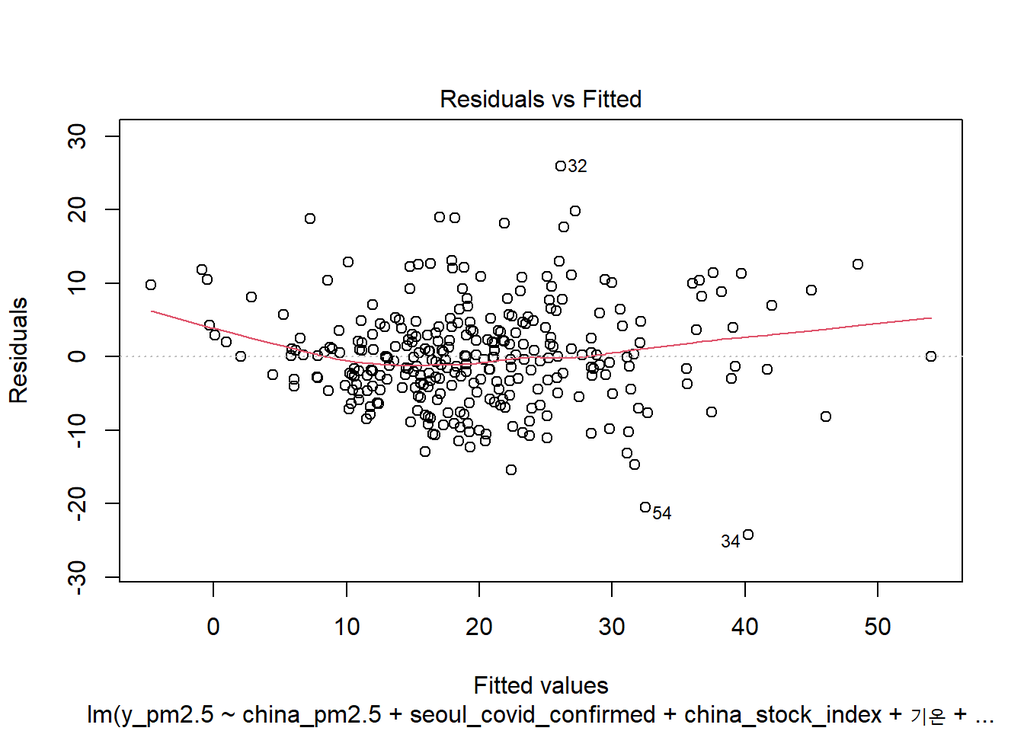

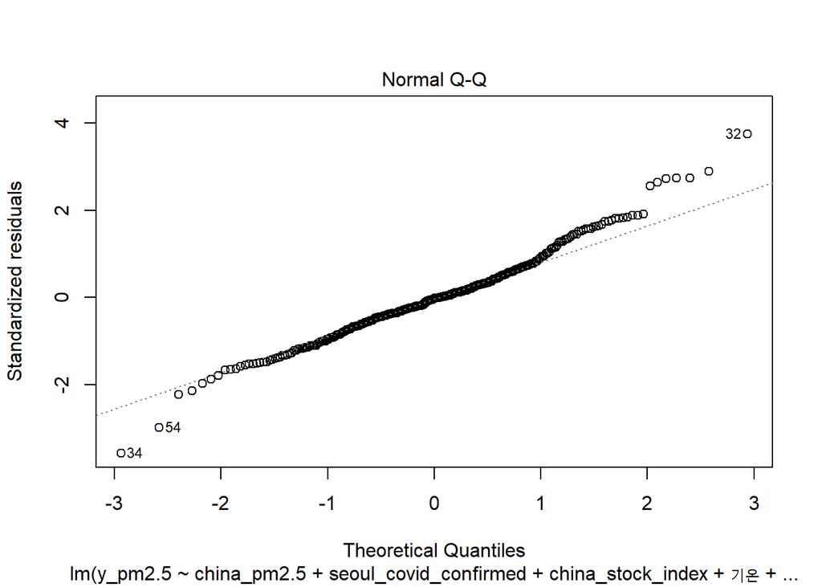

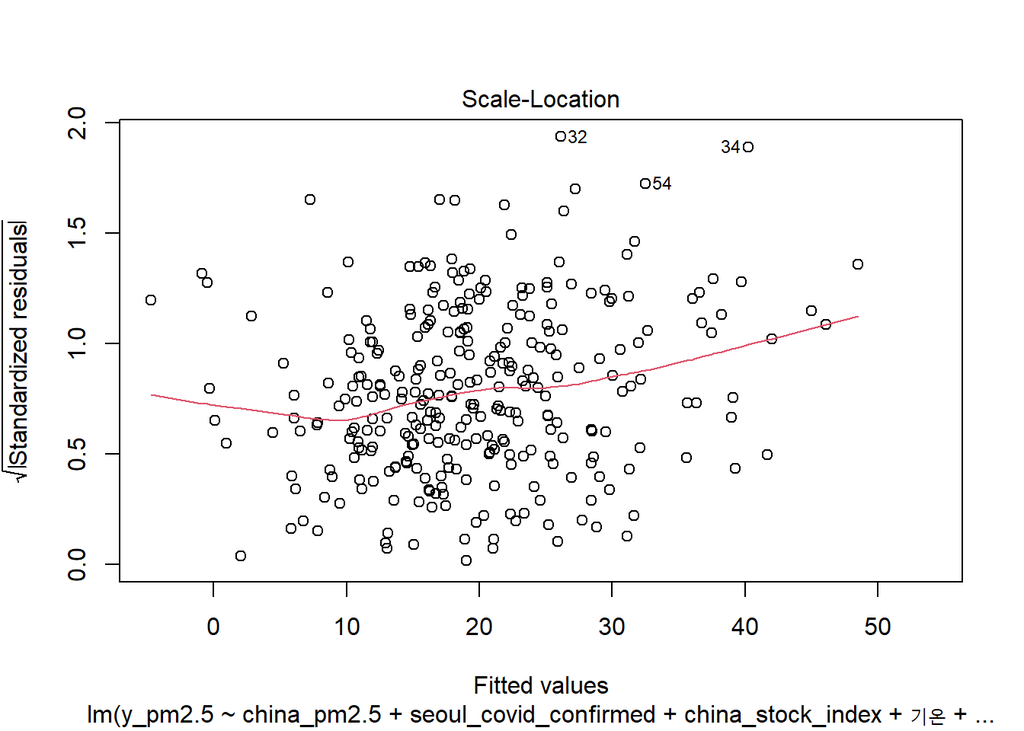

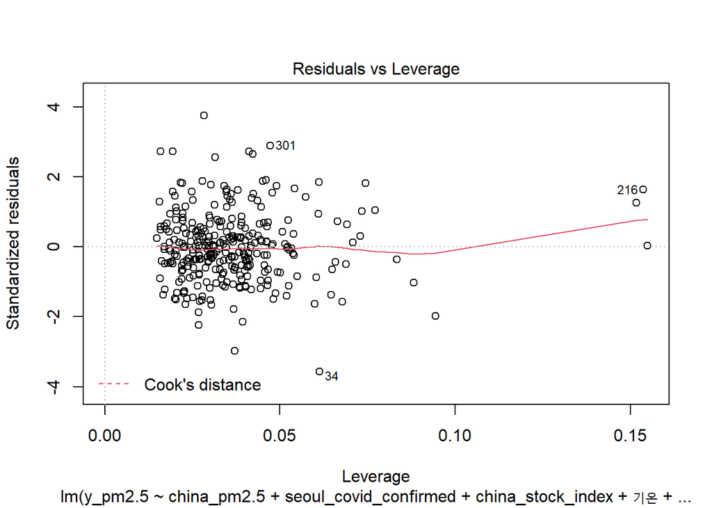

```r
plot(temp)
```

> Breush Pagan Test

```r
lmtest::bptest(temp)
```

```
##
##  studentized Breusch-Pagan test
##
## data:  temp
## BP = 24.354, df = 11, p-value = 0.01132
```

> Whites Test

```r
skedastic::white_lm(temp)
```

```
## # A tibble: 1 x 5
##   statistic p.value parameter method       alternative
##       <dbl>   <dbl>     <dbl> <chr>        <chr>
## 1      29.1   0.142        22 White's Test greater
```

## 6.2 자기상관

> Durbin & G.S. Watson Test for Serial Correlation in Least Squares Regression

```r
lmtest::dwtest(temp)
```

```
##
##  Durbin-Watson test
##
## data:  temp
## DW = 1.6871, p-value = 0.001045
## alternative hypothesis: true autocorrelation is greater than 0
```

> Breusch-Godfrey test

```r
lmtest::bgtest(temp, order=7)
```

```
##
##  Breusch-Godfrey test for serial correlation of order up to 7
##
## data:  temp
## LM test = 25.049, df = 7, p-value = 0.0007437
```

## 6.3 다중공선성

> vif

```
##     china_stock_index seoul_covid_confirmed                  습도
##              3.372412              2.383927              2.236193
##                  기온                강수량 soeul_oil_consumption
##              2.052437              1.490999              1.461187
##           y_pm2.5_lag              최다풍향           china_pm2.5
##              1.352109              1.323167              1.250834
##                  풍속              안개시간
##              1.120039              1.051331
```

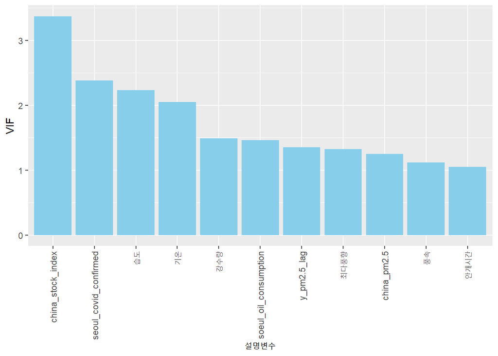

```r
car::vif(temp) %>%
  sort(decreasing=TRUE) %>%
  print() %>%
  as_tibble(rownames = 'label') %>%
  ggplot(aes(x=reorder(label, -value, sum), y=value)) +
  geom_col(fill='skyblue') +
  labs(x='설명변수', y='VIF') +
  theme(axis.text.x = element_text(angle = 90, vjust = 0.5, hjust=1))
```

> conditional index

```r
klaR::cond.index(formula = y_pm2.5 ~ china_pm2.5 + seoul_covid_confirmed +
                   china_stock_index + 기온 + 강수량 + 풍속 + 최다풍향 + 습도 +
                   안개시간 + soeul_oil_consumption + y_pm2.5_lag,
                 data = mutate(data20,y_pm2.5_lag=lag(y_pm2.5,1)))
```

```
##  [1]   1.000000   2.809850   2.962415   3.461687   5.282085   6.178769
##  [7]   8.025838   9.863004  13.923953  19.833154  38.064412 120.146037
```